# Untitled

Srikanth

July 4, 2016

## Reproducible Research Assignment 1

This is Project report for **Reproducible Research course** in Coursera.

# Introduction

This assignment makes use of data from a personal activity monitoring device. This device collects data at 5 minute intervals through out the day. The data consists of two months of data from an anonymous individual collected during the months of October and November, 2012 and include the number of steps taken in 5 minute intervals each day.

# Loading the data and the necessary pacakages for data analysis

```r
library(knitr)
opts_chunk$set(echo= TRUE)
data<-read.csv("activity.csv", header = TRUE)
head(data)
```

```
##   steps       date interval
## 1    NA 2012-10-01        0
## 2    NA 2012-10-01        5
## 3    NA 2012-10-01       10
## 4    NA 2012-10-01       15
## 5    NA 2012-10-01       20
## 6    NA 2012-10-01       25
```

```r
summary(data)
```

```
##      steps                date          interval
##  Min.   :  0.00   2012-10-01:  288   Min.   :   0.0
##  1st Qu.:  0.00   2012-10-02:  288   1st Qu.: 588.8
##  Median :  0.00   2012-10-03:  288   Median :1177.5
##  Mean   : 37.38   2012-10-04:  288   Mean   :1177.5
##  3rd Qu.: 12.00   2012-10-05:  288   3rd Qu.:1766.2
##  Max.   :806.00   2012-10-06:  288   Max.   :2355.0
##  NA's   :2304     (Other)   :15840
```

```r
data$date <- as.Date(data$date)
library(dplyr)
```

# Total, mean and median on the number of steps taken per day

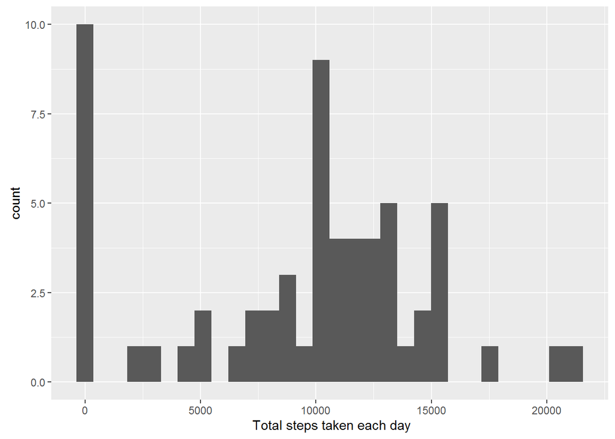

```r
library(ggplot2)
tsteps<-tapply(data$steps, data$date, FUN= sum, na.rm= TRUE)
qplot(tsteps, xlab=" Total steps taken each day")
```

```r
mean(tsteps, na.rm=TRUE)
```

```
## [1] 9354.23
```

```r
median(tsteps, na.rm=TRUE)
```

```
## [1] 10395
```

# Time series plot of the average number of steps taken

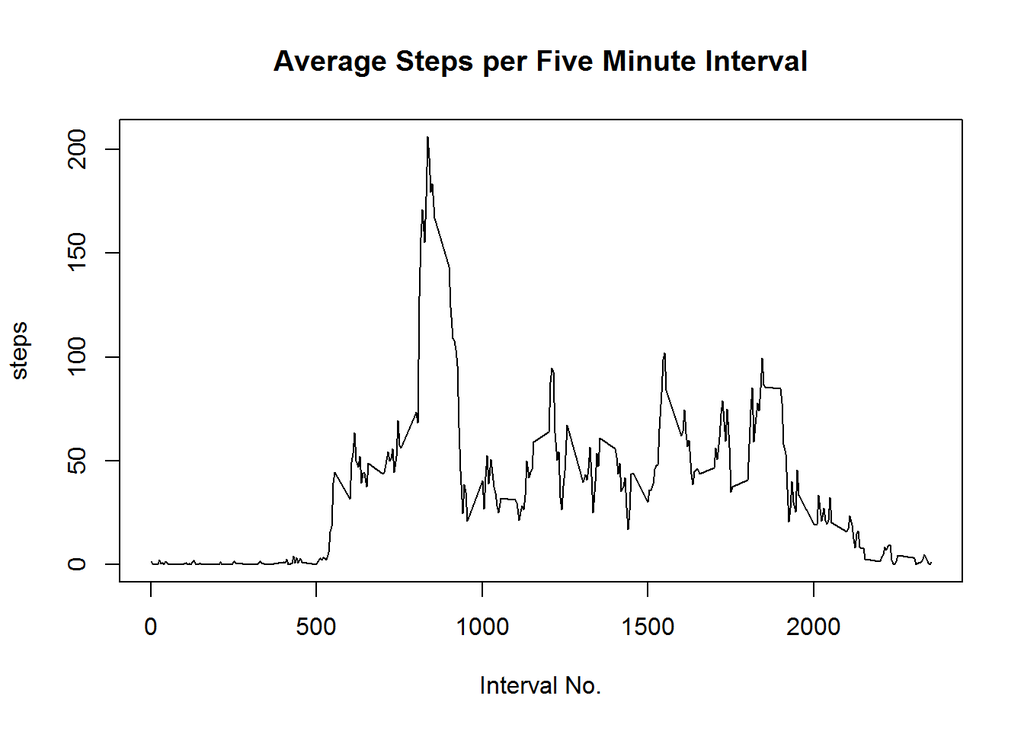

```r
aggdata<- aggregate(steps~interval, data=data, mean, na.rm=TRUE)
plot(aggdata$interval, aggdata$steps, type="l", main="Average Steps per Five Minute Interval",
     xlab="Interval No.", ylab="steps")
```

```r
maxi<-max(aggdata$steps)
```

# Imputing missing values

There are a lot of missing values in the data

```r
nrow(data[is.na(data),])
```

```
## [1] 2304
```

one of the strategy is to fill the missing values with the average number of steps in the same 5 minute interval

```r
data_full <- data
nas <- is.na(data_full$steps)
avg_interval <- tapply(data_full$steps, data_full$interval, mean, na.rm=TRUE, simplify=TRUE)
data_full$steps[nas] <- avg_interval[as.character(data_full$interval[nas])]
sum(is.na(data_full$steps))
```

```
## [1] 0
```

With the new data set after filling the missing values, the sum, mean and median is recalculated.

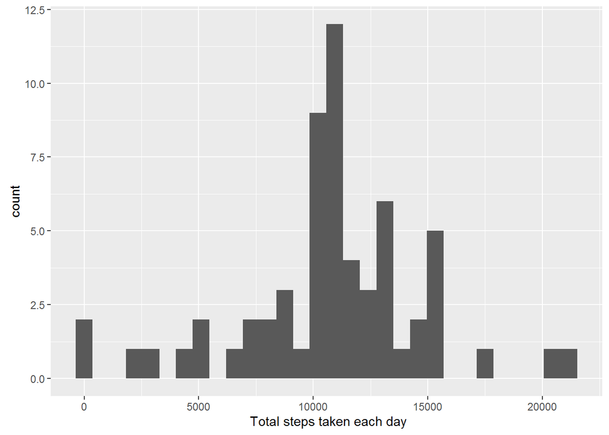

```r
library(ggplot2)
newtsteps<-tapply(data_full$steps, data_full$date, FUN= sum, na.rm=TRUE)
qplot(newtsteps, xlab=" Total steps taken each day")
```

```r
mean(newtsteps, na.rm=TRUE)
```

```
## [1] 10766.19
```

```r
median(newtsteps, na.rm=TRUE)
```

```
## [1] 10766.19
```

# Difference in activity patterns between weekdays and weekends

First step is to tag each day as a weekday or a weekend.

```r
data_full$day <- weekdays(as.Date(data_full$date))
data_full$dateTime<- as.POSIXct(data_full$date, format="%Y-%m-%d")
data_full$daycategory <- ifelse(data_full$day %in% c("Saturday", "Sunday"), "Weekend", "Weekday")
```

Next step is to plot two charts for a weekday and a weekend.

```r
library(plyr)
```

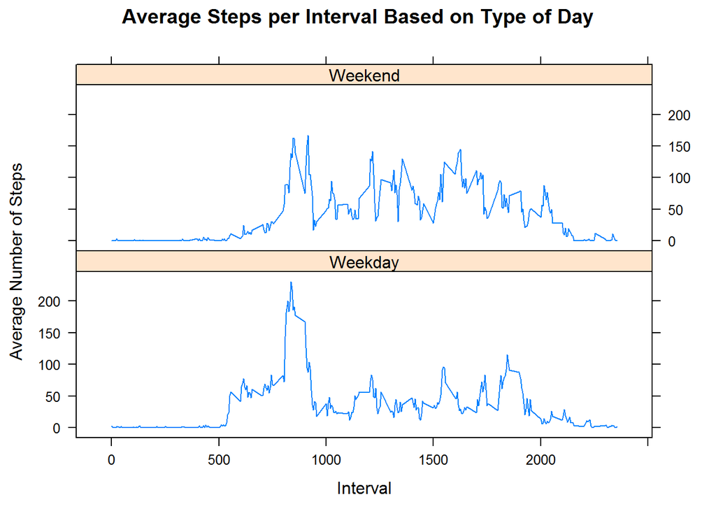

```r
library(lattice)
aggdata2 <- ddply(data_full, .(interval, daycategory), summarize, Avg = mean(steps))
##Plot data in a panel plot
xyplot(Avg~interval|daycategory, data=aggdata2, type="l",  layout = c(1,2),
       main="Average Steps per Interval Based on Type of Day",
       ylab="Average Number of Steps", xlab="Interval")
```